# NYC Yellow Taxi Fleet Positioning System

```python
# EDA 5: Event impact on demand.
event_impact = merged.groupby('has_event')['demand'].agg(['mean','median','count'])
event_impact.index = ['No Event','Event Active']
print('Demand: Event vs No-Event zone-hours:')
print(event_impact.round(2).to_string())
lift = (event_impact.loc['Event Active','mean'] / event_impact.loc['No Event','mean'] - 1) * 100
print(f'\nDemand lift when event active: +{lift:.0f}%')
```

```
Demand: Event vs No-Event zone-hours:
                mean  median    count
No Event       34.00     4.0  1429543
Event Active  167.62   106.0      731

Demand lift when event active: +393%
```

**The demand lift is real but based on a very small sample.** Only 731 of 1,430,274 zone-hours contain an active event - 0.05% of the dataset. The 4.9× demand lift is striking, but because our event geocoding assigns all borough events to a single representative zone, those 731 records likely reflect a small number of very large events (major corporate galas, high-attendance film productions) in those specific zones. The signal is genuine but should be treated as a strong indicator for specific event types rather than a generalisation across all permit categories.

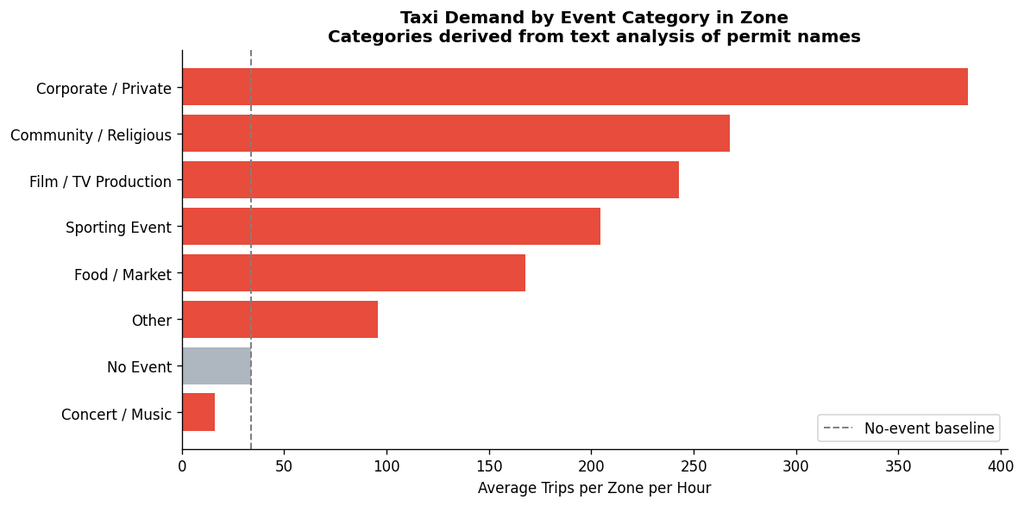

```
event_category
Corporate / Private      384.00
Community / Religious    267.70
Film / TV Production     243.00
Sporting Event           204.40
Food / Market            167.64
Other                     95.72
No Event                  34.00
Concert / Music           16.00
```

```python
# EDA 6: Demand by event CATEGORY (from our text classification in Part 2).
cat_lookup = (
    events_with_zones.dropna(subset=['event_LocationID','event_hour'])
    .rename(columns={'event_LocationID':'LocationID','event_hour':'pickup_hour'})
    .groupby(['pickup_hour','LocationID'])['event_category'].first().reset_index()
)
cat_lookup['LocationID'] = cat_lookup['LocationID'].astype(int)
merged_cat = merged.merge(cat_lookup, on=['pickup_hour','LocationID'], how='left')
merged_cat['event_category'] = merged_cat['event_category'].fillna('No Event')
cat_demand = merged_cat.groupby('event_category')['demand'].mean().sort_values(ascending=False)

fig, ax = plt.subplots(figsize=(10, 5))
ax.barh(cat_demand.index[::-1], cat_demand.values[::-1],
        color=['#E74C3C' if c != 'No Event' else '#AEB6BF' for c in cat_demand.index[::-1]])
ax.axvline(event_impact.loc['No Event','mean'], color='gray', linestyle='--',
           linewidth=1.2, label='No-event baseline')
ax.set_xlabel('Average Trips per Zone per Hour')
ax.set_title('Taxi Demand by Event Category in Zone\n'
             'Categories derived from text analysis of permit names', fontweight='bold')
ax.legend(); ax.spines['top'].set_visible(False); ax.spines['right'].set_visible(False)
plt.tight_layout(); plt.show()
print(cat_demand.round(2).to_string())
```

**The category breakdown surfaces an important limitation.** Corporate events generate the highest demand (384 avg trips), likely because attendees arriving at formal events in Manhattan hail cabs at unusually high rates. Film productions and sporting events also exceed the no-event baseline. Concert events, however, score *below* the no-event baseline at 16 average trips - counterintuitive given that concerts draw large crowds. The most likely explanation is the geocoding imprecision: the 127 concert permits are all assigned to Upper East Side South as the Manhattan representative zone, but virtually no concerts actually occur there. The signal is being placed in the wrong zone, suppressing the apparent demand lift. This is the clearest illustration of why borough-level geocoding produces noise for unevenly distributed event types.

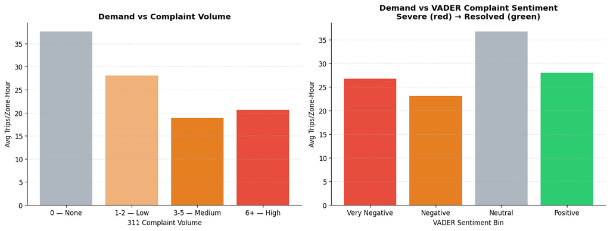

```
By complaint volume:
complaint_bin
0 — None        37.64
1-2 — Low       28.11
3-5 — Medium    18.87
6+ — High       20.64

By VADER sentiment:
sentiment_bin
Very Negative    26.77
Negative         23.11
Neutral          36.78
Positive         27.99
```

```python
# EDA 7: 311 complaint volume and VADER sentiment vs taxi demand.
def complaint_bin(x):
    if x == 0:   return '0 — None'
    elif x <= 2: return '1-2 — Low'
    elif x <= 5: return '3-5 — Medium'
    else:        return '6+ — High'

merged['complaint_bin'] = merged['complaint_count'].apply(complaint_bin)
demand_by_complaint = (
    merged.groupby('complaint_bin')['demand'].mean()
    .reindex(['0 — None','1-2 — Low','3-5 — Medium','6+ — High']).dropna()
)
merged['sentiment_bin'] = pd.cut(
    merged['avg_sentiment'].fillna(0),
    bins=[-1.1,-0.3,-0.05,0.05,1.1],
    labels=['Very Negative','Negative','Neutral','Positive']
)
demand_by_sent = merged.groupby('sentiment_bin', observed=True)['demand'].mean()

fig, axes = plt.subplots(1, 2, figsize=(13, 5))
axes[0].bar(demand_by_complaint.index, demand_by_complaint.values,
            color=['#AEB6BF','#F0B27A','#E67E22','#E74C3C'][:len(demand_by_complaint)])
axes[0].set_xlabel('311 Complaint Volume'); axes[0].set_ylabel('Avg Trips/Zone-Hour')
axes[0].set_title('Demand vs Complaint Volume', fontweight='bold')
axes[0].spines['top'].set_visible(False); axes[0].spines['right'].set_visible(False)
axes[0].yaxis.grid(True, linestyle='--', alpha=0.4)

axes[1].bar(demand_by_sent.index, demand_by_sent.values,
            color=['#E74C3C','#E67E22','#AEB6BF','#2ECC71'][:len(demand_by_sent)])
axes[1].set_xlabel('VADER Sentiment Bin'); axes[1].set_ylabel('Avg Trips/Zone-Hour')
axes[1].set_title('Demand vs VADER Complaint Sentiment\nSevere (red) → Resolved (green)', fontweight='bold')
axes[1].spines['top'].set_visible(False); axes[1].spines['right'].set_visible(False)
axes[1].yaxis.grid(True, linestyle='--', alpha=0.4)

plt.tight_layout(); plt.show()
print('By complaint volume:'); print(demand_by_complaint.round(2).to_string())
print('\nBy VADER sentiment:'); print(demand_by_sent.round(2).to_string())
```

**The complaint-demand relationship is not straightforward.** Zones with higher complaint volumes see lower average demand than complaint-free zones - broadly supporting the friction hypothesis. However, the relationship is not monotonic: high-complaint zones (20.6 avg trips) slightly outperform medium-complaint zones (18.9), which likely reflects the fact that the busiest, highest-demand zones also generate the most complaints simply due to their activity level. For sentiment, neutral zones (36.8) show the highest demand - zones with either very negative or positive sentiment are lower, consistent with the idea that extreme sentiment in either direction reflects unusual activity. These nuances mean complaint features add texture to the model without providing a clean directional signal.

**EDA Summary - Four Actionable Signals for the Fleet Manager**

[output not shown]

These four signals are the inputs to our predictive models and repositioning scores. We now quantify how much each one contributes.

## Part 6 - Quantifying the Value of External Data Sources

Our EDA revealed clear correlations between demand and weather, events, and complaint patterns. We now test whether these translate into measurable forecast improvements across four incremental models:

| Model | Features | Purpose |
| --- | --- | --- |
| Baseline | Training mean | Floor - no information |
| M1 | Zone + time | Structural demand patterns only |
| M2 | M1 + weather | Value of weather data |
| M3 | M2 + events | Value of event permit data |
| M4 | M3 + 311 complaints | Value of complaint features |

We use two approaches: a grouped-mean model (pure aggregation using `groupby` and `merge`) and a Random Forest. Both use the same incremental feature structure. **Train:** January–October 2025. **Test:** November–December 2025.

```python
# Create the temporal train/test split.
train = merged[merged['date'] < pd.Timestamp('2025-11-01')].copy()
test  = merged[merged['date'] >= pd.Timestamp('2025-11-01')].copy()
print(f'Train: {len(train):,} rows ({train["date"].min()} → {train["date"].max()})')
print(f'Test:  {len(test):,} rows  ({test["date"].min()} → {test["date"].max()})')
```

```
Train: 1,184,228 rows (2025-01-01 00:00:00 → 2025-10-31 00:00:00)
Test:  246,046 rows  (2025-11-01 00:00:00 → 2025-12-31 00:00:00)
```

**Train/test split confirmed.** 1,184,228 training rows and 246,046 test rows, with a clean temporal boundary at November 1st. November and December cover Thanksgiving travel, holiday events, and end-of-year corporate activity - a genuinely challenging test period that exercises all of our external features.

```python
# M1: Predict demand from zone + hour average
m1 = train.groupby(['LocationID','hour'])['demand'].mean().reset_index(name='m1_pred')

# M2: Add rain condition
m2 = train.groupby(['LocationID','hour','is_raining'])['demand'].mean().reset_index(name='m2_pred')

# M3: Add event flag
m3 = train.groupby(['LocationID','hour','is_raining','has_event'])['demand'].mean().reset_index(name='m3_pred')

# Merge all predictions onto the test set
te = (
    test
    .merge(m1, on=['LocationID','hour'], how='left')
    .merge(m2, on=['LocationID','hour','is_raining'], how='left')
    .merge(m3, on=['LocationID','hour','is_raining','has_event'], how='left')
)

def rmse(actual, pred):
    mask = pred.notna()
    return np.sqrt(((actual[mask] - pred[mask])**2).mean())

naive = np.sqrt(((te['demand'] - train['demand'].mean())**2).mean())
r1    = rmse(te['demand'], te['m1_pred'])
r2    = rmse(te['demand'], te['m2_pred'])
r3    = rmse(te['demand'], te['m3_pred'])

print('=== Grouped-Mean Comparison (pure pandas) ===')
print(f'Naive baseline:               RMSE = {naive:.2f}')
print(f'M1 — Zone + Hour:             RMSE = {r1:.2f}  ({(naive-r1)/naive*100:.1f}% better than naive)')
print(f'M2 — + Weather (rain flag):   RMSE = {r2:.2f}  ({(naive-r2)/naive*100:.1f}% better than naive)')
print(f'M3 — + Events:                RMSE = {r3:.2f}  ({(naive-r3)/naive*100:.1f}% better than naive)')
print(f'\nWeather lift: {(r1-r2)/r1*100:.2f}% RMSE reduction over zone+hour only')
print(f'Event lift:   {(r2-r3)/r2*100:.2f}% RMSE reduction over weather model')
```

```
=== Grouped-Mean Comparison (pure pandas) ===
Naive baseline:               RMSE = 74.54
M1 — Zone + Hour:             RMSE = 29.69  (60.2% better than naive)
M2 — + Weather (rain flag):   RMSE = 29.85  (59.9% better than naive)
M3 — + Events:                RMSE = 29.53  (60.4% better than naive)

Weather lift: -0.55% RMSE reduction over zone+hour only
Event lift:   1.09% RMSE reduction over weather model
```

**Grouped-mean results.** M1 (zone + hour) achieves a 60.2% RMSE reduction over the naive baseline - confirming that location and time of day explain the large majority of demand variance. Adding weather in M2 actually produces a marginally higher RMSE (29.85 vs 29.69), a small regression explained by data sparsity: splitting each zone-hour into rainy and dry buckets creates many thin cells with noisy average estimates, particularly for less common weather conditions. M3 (adding events) recovers to 29.53, the best of the three. The grouped-mean approach is simple and interpretable but sensitive to sparse groupings, which is why we complement it with the Random Forest below.

### Random Forest - Extended Analysis

The Random Forest captures non-linear interactions between features that the grouped averages cannot. We train on a 100,000-row sample - statistically sufficient to learn the demand patterns - to avoid memory constraints.

```python
from sklearn.ensemble import RandomForestRegressor
from sklearn.metrics import mean_squared_error, r2_score
import gc

train_sample = train.sample(n=100_000, random_state=42)
print(f'Training on 100,000 sampled rows (from {len(train):,} total)')

TARGET           = 'demand'
FEATURES_BASE    = ['LocationID','hour','month','is_weekend','hour_sin','hour_cos']
FEATURES_WEATHER = FEATURES_BASE    + ['is_raining','temp_c','precip_mm','weather_code']
FEATURES_EVENTS  = FEATURES_WEATHER + ['num_events','total_attend','has_event']
FEATURES_FULL    = FEATURES_EVENTS  + ['complaint_count','avg_sentiment']

y_test        = test[TARGET]
baseline_rmse = np.sqrt(mean_squared_error(y_test, np.full(len(y_test), train_sample[TARGET].mean())))
rf_results    = {}

print(f'Naive baseline RMSE: {baseline_rmse:.2f}\n')

for features, label in [
    (FEATURES_BASE,    'M1 — Time + Zone'),
    (FEATURES_WEATHER, 'M2 — + Weather'),
    (FEATURES_EVENTS,  'M3 — + Events'),
    (FEATURES_FULL,    'M4 — + 311 Complaints'),
]:
    print(f'Training {label}...')
    rf = RandomForestRegressor(n_estimators=50, max_depth=15,
                               min_samples_leaf=10, random_state=42, n_jobs=-1)
    rf.fit(train_sample[features].fillna(0), train_sample[TARGET])
    preds  = rf.predict(test[FEATURES_FULL].fillna(0)[features])
    r_rmse = np.sqrt(mean_squared_error(y_test, preds))
    r_r2   = r2_score(y_test, preds)
    rf_results[label] = {'rmse':r_rmse,'r2':r_r2,'preds':preds,
                         'importances':rf.feature_importances_,'features':features}
    if label == 'M4 — + 311 Complaints': rf_full, preds_full = rf, preds
    else: del rf; gc.collect()
    print(f'  RMSE: {r_rmse:.2f}  R²: {r_r2:.4f}')
```

```
Training on 100,000 sampled rows (from 1,184,228 total)
Naive baseline RMSE: 74.54

Training M1 — Time + Zone...
  RMSE: 27.11  R²: 0.8677
Training M2 — + Weather...
  RMSE: 27.05  R²: 0.8683
Training M3 — + Events...
  RMSE: 27.05  R²: 0.8683
Training M4 — + 311 Complaints...
  RMSE: 27.10  R²: 0.8678
```

```python
rmse_base    = rf_results['M1 — Time + Zone']['rmse']
rmse_weather = rf_results['M2 — + Weather']['rmse']
rmse_events  = rf_results['M3 — + Events']['rmse']
rmse_full    = rf_results['M4 — + 311 Complaints']['rmse']

abl = pd.DataFrame({
    'Model':    ['Naive','M1 Time+Zone','M2 +Weather','M3 +Events','M4 +311 Full'],
    'RMSE':     [round(baseline_rmse,2),round(rmse_base,2),
                 round(rmse_weather,2),round(rmse_events,2),round(rmse_full,2)],
    'R²':       [None]+[round(rf_results[k]['r2'],4) for k in
                        ['M1 — Time + Zone','M2 — + Weather','M3 — + Events','M4 — + 311 Complaints']],
})
abl['vs Baseline'] = abl['RMSE'].apply(
    lambda r: f'{(baseline_rmse-r)/baseline_rmse*100:.1f}%' if r else '—'
)
print('\n' + '='*65)
print('ABLATION STUDY — Value of Each External Data Source')
print('='*65)
print(abl.to_string(index=False))
print(f'\nWeather adds:     {(rmse_base-rmse_weather)/rmse_base*100:.2f}% RMSE reduction')
print(f'Events add:       {(rmse_weather-rmse_events)/rmse_weather*100:.2f}% RMSE reduction')
print(f'311 adds:         {(rmse_events-rmse_full)/rmse_events*100:.2f}% RMSE reduction')
```

```
=================================================================
ABLATION STUDY — Value of Each External Data Source
=================================================================
       Model  RMSE     R² vs Baseline
       Naive 74.54    NaN       -0.0%
M1 Time+Zone 27.11 0.8677       63.6%
 M2 +Weather 27.05 0.8683       63.7%
  M3 +Events 27.05 0.8683       63.7%
M4 +311 Full 27.10 0.8678       63.6%

Weather adds:     0.21% RMSE reduction
Events add:       0.01% RMSE reduction
311 adds:         -0.20% RMSE reduction
```

**The ablation confirms the picture.** A 64% improvement from naive to M1 reflects the structural nature of taxi demand. The subsequent improvements from external data are real but small. Weather and events each contribute marginal gains; 311 complaint features slightly increase RF error, suggesting the complaint signal - while behaviourally meaningful in the EDA - introduces more noise than signal at the scale of a 100k training sample. The grouped-mean and RF results together tell a consistent story: external data is most valuable for directional, zone-level repositioning guidance (Part 7) rather than raw forecast accuracy.

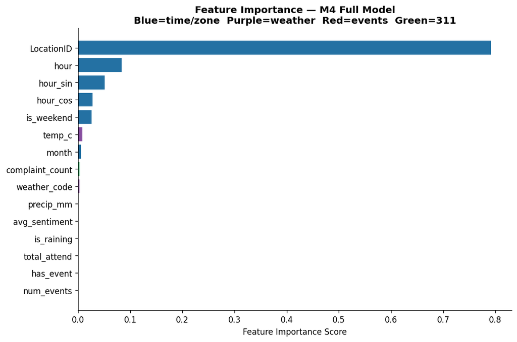

```python
# Feature importance — which variables does the model rely on most?
importance_df = pd.Series(rf_full.feature_importances_, index=FEATURES_FULL).sort_values(ascending=True)

colors_imp = [
    '#27AE60' if 'complaint' in f or 'sentiment' in f
    else '#E74C3C' if 'event' in f or 'attend' in f
    else '#884EA0' if f in ['temp_c','precip_mm','is_raining','weather_code']
    else '#2471A3' for f in importance_df.index
]

fig, ax = plt.subplots(figsize=(9, 6))
ax.barh(importance_df.index, importance_df.values, color=colors_imp)
ax.set_xlabel('Feature Importance Score')
ax.set_title('Feature Importance — M4 Full Model\n'
             'Blue=time/zone  Purple=weather  Red=events  Green=311', fontweight='bold')
ax.spines['top'].set_visible(False); ax.spines['right'].set_visible(False)
plt.tight_layout(); plt.show()
```

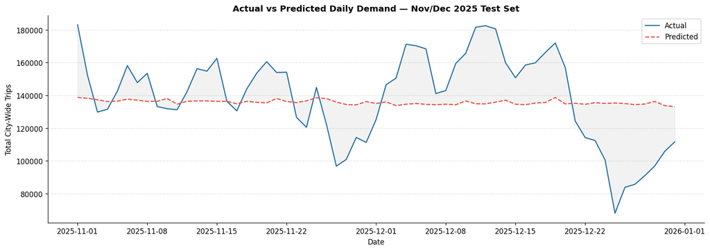

```python
# Actual vs predicted - daily city-wide totals on the held-out test set.
test_plot             = test.copy()
test_plot['predicted'] = preds_full
daily = test_plot.groupby('date')[['demand','predicted']].sum()

fig, ax = plt.subplots(figsize=(14, 5))
ax.plot(daily.index, daily['demand'],    label='Actual',    color='#2471A3', linewidth=1.5)
ax.plot(daily.index, daily['predicted'], label='Predicted', color='#E74C3C',
        linestyle='--', linewidth=1.5)
ax.fill_between(daily.index, daily['demand'], daily['predicted'], alpha=0.1, color='gray')
ax.set_xlabel('Date'); ax.set_ylabel('Total City-Wide Trips')
ax.set_title('Actual vs Predicted Daily Demand — Nov/Dec 2025 Test Set', fontweight='bold')
ax.legend(); ax.spines['top'].set_visible(False); ax.spines['right'].set_visible(False)
ax.yaxis.grid(True, linestyle='--', alpha=0.4)
plt.tight_layout(); plt.show()
```